# R Notebook

In this homework we will create a decision tree to see which factors are useful in predicting whether or not a passenger on the titanic will survive.

Run the code below before you begin:

```r
library(rpart)
library(rpart.plot)
library(tidyverse)

library(tidyverse)
titanic_set <- read_csv('data/titanic_decision_tree_data.csv')
```

```
* `` -> ...1
```

```r
shuffle_index <- sample(1:nrow(titanic_set))

# shuffle the data so class order isn't in order - need this for training/testing split later on
titanic_set <- titanic_set[shuffle_index, ]
```

**Data Dictionary**

- **sex**: Biological Sex, male or female
- **age_status**: adult or child (child defined as under 16)
- **class** : Ticket class, 1 = 1st (Upper class), 2 = 2nd (Middle Class), 3 = 3rd (Lower Class)
- **port_embarkation**: C = Cherbourg, Q = Queenstown, S = Southampton
- **sibsp** : number of siblings / spouses aboard the Titanic
- **parch**: number of parents / children aboard the Titanic. Some children travelled only with a nanny, therefore parch=0 for them.
- **survived_flag** : did they survive, 0 = No, 1 = Yes

# MVP

## Question 1

Cleaning up the data is always the first step. Do the following:

- Take only observations which have a `survived` flag (i.e. that aren’t missing)
- Turn your important variables into factors (sex, survived, pclass, embarkation)
- Create an `age_status` variable which groups individuals under (and including) 16 years of age into a category called “child” category and those over 16 into a category called “adult”.
- Drop the NA
- Drop any variables you don’t need (`X1`, `passenger_id`, `name`, `ticket`, `far`, `cabin`)

**Ans**

View data:

```r
titanic_set %>%
  glimpse()
```

```
Rows: 1,309
Columns: 13
$ ...1         <dbl> 220, 764, 187, 536, 251, 1012, 1208, 315, 397, 543, 823, 567, 750, 799, 166, 125, 156, 161, 632, 385, 628, 346, ~
$ passenger_id <dbl> 1111, 346, 1078, 118, 1142, 594, 790, 1206, 1288, 125, 405, 149, 332, 381, 1057, 1016, 1047, 1052, 214, 1276, 21~
$ pclass       <dbl> 3, 2, 2, 2, 2, 3, 1, 1, 3, 1, 3, 2, 1, 1, 3, 3, 3, 3, 2, 2, 1, 3, 3, 3, 1, 1, 1, 3, 3, 3, 3, 3, 3, 3, 2, 2, 2, 2~
$ name         <chr> "Thomson, Mr. Alexander Morrison", "Brown, Miss. Amelia \"Mildred\"", "Phillips, Miss. Alice Frances Louisa", "T~
$ sex          <chr> "male", "female", "female", "male", "female", "female", "male", "female", "male", "male", "female", "male", "mal~
$ age          <dbl> NA, 24.00, 21.00, 29.00, 0.92, NA, 46.00, 55.00, 24.00, 54.00, 20.00, 36.50, 45.50, 42.00, 26.00, NA, 24.00, NA,~
$ sib_sp       <dbl> 0, 0, 0, 1, 1, 0, 0, 0, 0, 0, 0, 0, 0, 0, 1, 0, 0, 0, 0, 0, 0, 0, 0, 1, 0, 0, 0, 1, 0, 0, 0, 0, 1, 0, 0, 0, 0, 1~
$ parch        <dbl> 0, 0, 1, 0, 2, 2, 0, 0, 0, 1, 0, 2, 0, 0, 1, 0, 0, 0, 0, 0, 0, 0, 1, 5, 0, 0, 0, 0, 0, 0, 0, 1, 0, 0, 0, 0, 0, 0~
$ ticket       <chr> "32302", "248733", "S.O./P.P. 2", "11668", "C.A. 34651", "364848", "PC 17593", "PC 17760", "371109", "35281", "3~
$ fare         <dbl> 8.0500, 13.0000, 21.0000, 21.0000, 27.7500, 7.7500, 79.2000, 135.6333, 7.2500, 77.2875, 8.6625, 26.0000, 28.5000~
$ cabin        <chr> NA, "F33", NA, NA, NA, NA, "B82 B84", "C32", NA, "D26", NA, "F2", "C124", NA, NA, NA, NA, NA, NA, NA, "A31", NA,~
$ embarked     <chr> "S", "S", "S", "S", "S", "Q", "C", "C", "Q", "S", "S", "S", "S", "C", "S", "Q", "S", "Q", "S", "S", "C", "S", "C~
$ survived     <dbl> NA, 1, NA, 0, NA, 0, 0, NA, NA, 0, 0, 0, 0, 1, NA, NA, NA, NA, 0, NA, 1, NA, 1, 0, 0, 1, 0, 0, 0, NA, NA, 1, NA,~
```

Check for NA values:

```r
titanic_set %>%
  summarise(across(.cols = everything(),
                   .fns = ~sum(is.na(.x))))
```

| ...1 | passenger_id | pclass | name | sex | age | sib_sp | parch | ticket | fare | cabin | embarked | survived |
| --- | --- | --- | --- | --- | --- | --- | --- | --- | --- | --- | --- | --- |
| 0 | 0 | 0 | 0 | 0 | 263 | 0 | 0 | 0 | 1 | 1014 | 2 | 418 |

```r
NA
```

Clean-up data (if you follow blindly the instructions above, the resulting dataset will have very few rows (about 183) because drop_na() is not called at the end of the code chunk):

```r
titanic_clean <- titanic_set %>%
  # remove observations which have a ``survived`` flag equal to NA
  filter(!is.na(survived))  %>%
  # create an ``age_status`` variable and factor important variables
  mutate(
    sex = as.factor(sex),
    survived = factor(survived, levels = c(0,1), labels = c("No", "Yes")),
    pclass = factor(pclass, levels = c(1, 2, 3), labels = c("Upper", "Middle", "Lower")),
    embarked = as.factor(embarked),
    age_status = as.factor(if_else(age <= 16, "child", "adult"))
  ) %>%
  # keep useful variables
  select(sex, survived, pclass, embarked, age_status, sib_sp, parch) %>%
  # drop NA values
  drop_na()

glimpse(titanic_clean)
```

```
Rows: 712
Columns: 7
$ sex        <fct> female, male, male, male, female, male, male, female, male, male, male, male, male, female, female, male, female, ~
$ survived   <fct> Yes, No, No, No, No, No, No, Yes, No, Yes, Yes, No, No, Yes, No, No, Yes, No, No, Yes, No, Yes, No, No, No, No, Ye~
$ pclass     <fct> Middle, Middle, Upper, Upper, Lower, Middle, Upper, Upper, Middle, Upper, Lower, Lower, Upper, Upper, Lower, Lower~
$ embarked   <fct> S, S, C, S, S, S, S, C, S, C, C, S, S, C, S, S, C, S, S, S, S, S, S, S, S, S, C, S, S, C, S, Q, Q, S, C, S, C, S, ~
$ age_status <fct> adult, adult, adult, adult, adult, adult, adult, adult, adult, adult, child, adult, adult, adult, adult, adult, ch~
$ sib_sp     <dbl> 0, 1, 0, 0, 0, 0, 0, 0, 0, 0, 0, 1, 0, 0, 1, 0, 0, 0, 0, 0, 1, 0, 1, 0, 1, 0, 2, 5, 1, 0, 0, 0, 0, 1, 0, 1, 0, 0, ~
$ parch      <dbl> 0, 0, 0, 1, 0, 2, 0, 0, 0, 0, 1, 5, 0, 0, 0, 0, 1, 0, 0, 0, 0, 1, 0, 0, 0, 0, 1, 2, 2, 2, 2, 0, 0, 0, 0, 1, 0, 0, ~
```

Check for NA values:

```r
titanic_clean %>%
  summarise(across(.cols = everything(),
                   .fns = ~sum(is.na(.x))))
```

| sex | survived | pclass | embarked | age_status | sib_sp | parch |
| --- | --- | --- | --- | --- | --- | --- |
| 0 | 0 | 0 | 0 | 0 | 0 | 0 |

```r
NA
```

## Question 2

Have a look at your data and create some plots to ensure you know what you’re working with before you begin. Write a summary of what you have found in your plots. Which variables do you think might be useful to predict whether or not people are going to die? Knowing this before you start is the best way to have a sanity check that your model is doing a good job.

**Ans** To find relationships between variables, split data in numeric and non-numeric

```r
titanic_clean_numeric <- titanic_clean %>%
  select_if(is.numeric)

titanic_clean_numeric$survived <- titanic_clean$survived



titanic_clean_nonnumeric <- titanic_clean %>%
  select_if(function(x) !is.numeric(x))
```

View correlations

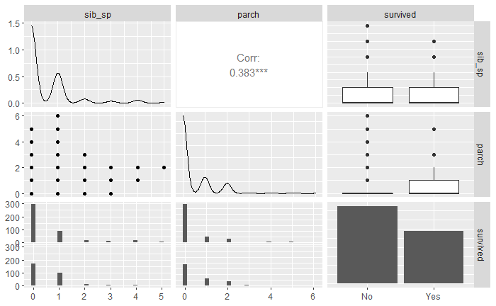

```r
library(GGally)

titanic_clean_numeric %>%
  ggpairs()
```

[output not shown]

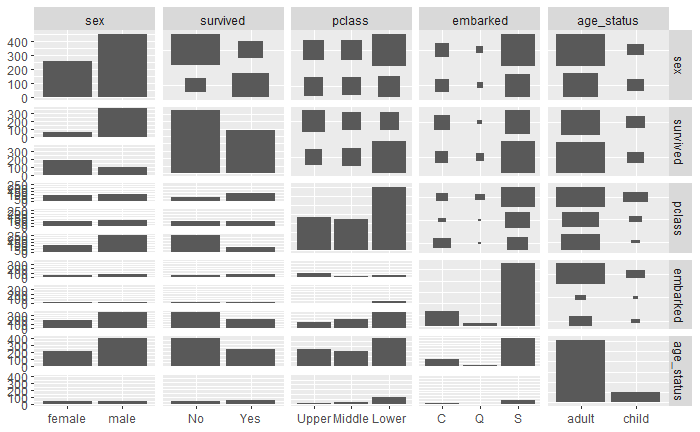

```r
titanic_clean_nonnumeric %>%
  ggpairs()
```

Check if `parch` is worth including in variables useful for prediction:

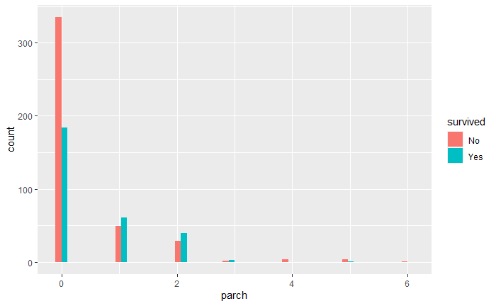

```r
titanic_clean_numeric %>%
  ggplot() +
  aes(x = parch, fill = survived) +
  geom_histogram(position = "dodge")
```

```r
NA
```

Variables that are likely to be useful for prediction:

- `parch` (the histogram distribution with `survived` variable shows some variation)
- `embrarked` (the bar plots with `survived` show some variation)
- `pclass` (the bar plots with `survived` show some variation)
- `sex` (the bar plots with `survived` show some variation)
- `age_status` (the bar plots with `survived` show some variation)

## Question 3

Now you can start to build your model. Create your testing and training set using an appropriate split. Check you have balanced sets. Write down why you chose the split you did and produce output tables to show whether or not it is balanced. [**Extra** - if you want to force balanced testing and training sets, have a look at the `stratified()` function in package `splitstackshape` (you can specify multiple variables to stratify on by passing a vector of variable names to the `group` argument, and get back testing and training sets with argument `bothSets = TRUE`)]

**Ans**

```r
# set the random seed number
set.seed(45678)
```

Case#1: 80-20 split without stratification:

```r
n_data <- nrow(titanic_clean)

# create a test sample index
test_index <- sample(1:n_data, size = n_data*0.2)

# create test set
titanic_test  <- slice(titanic_clean, test_index)

# create training set
titanic_train <- slice(titanic_clean, -test_index)
```

```r
# check balanced sets
titanic_test %>%
 janitor::tabyl(survived)
```

```
 survived  n   percent
       No 81 0.5704225
      Yes 61 0.4295775
```

```r
titanic_train %>%
  janitor::tabyl(survived)
```

```
 survived   n   percent
       No 343 0.6017544
      Yes 227 0.3982456
```

Case#2: 80-20 split with stratification per the variables shown below (I didn’t stratify per `parch` because there weren’t enough rows for all distinct groups):

```r
library(splitstackshape)

sets <- stratified(titanic_clean, group = c("survived", "embarked", "pclass", "sex", "age_status"), bothSets = TRUE, size = 0.2)

titanic_test_strat <- sets$SAMP1
titanic_train_strat <- sets$SAMP2


tibble(
  nrows_testing_strat = nrow(titanic_test_strat),
  nrows_training_strat = nrow(titanic_train)
)
```

[output not shown]

Check percentages of stratified variables (testing and training)

1. Variable `survived`

```r
titanic_test_strat %>%
 janitor::tabyl(survived)
```

```
 survived  n   percent
       No 83 0.5971223
      Yes 56 0.4028777
```

```r
titanic_train_strat %>%
 janitor::tabyl(survived)
```

```
 survived   n   percent
       No 341 0.5951134
      Yes 232 0.4048866
```

2. Variable `embarked`

```r
titanic_test_strat %>%
 janitor::tabyl(embarked)
```

```
 embarked   n    percent
        C  23 0.16546763
        Q   5 0.03597122
        S 111 0.79856115
```

```r
titanic_train_strat %>%
 janitor::tabyl(embarked)
```

```
 embarked   n    percent
        C 107 0.18673647
        Q  23 0.04013962
        S 443 0.77312391
```

3. Variable `pclass`

```r
titanic_test_strat %>%
 janitor::tabyl(pclass)
```

```
 pclass  n   percent
  Upper 36 0.2589928
 Middle 33 0.2374101
  Lower 70 0.5035971
```

```r
titanic_train_strat %>%
 janitor::tabyl(pclass)
```

```
 pclass   n   percent
  Upper 148 0.2582897
 Middle 140 0.2443281
  Lower 285 0.4973822
```

4. Variable `sex`

```r
titanic_test_strat %>%
 janitor::tabyl(sex)
```

```
    sex  n   percent
 female 50 0.3597122
   male 89 0.6402878
```

```r
titanic_train_strat %>%
 janitor::tabyl(sex)
```

```
    sex   n   percent
 female 209 0.3647469
   male 364 0.6352531
```

5. Variable `age_status`

```r
titanic_test_strat %>%
 janitor::tabyl(age_status)
```

```
 age_status   n   percent
      adult 119 0.8561151
      child  20 0.1438849
```

```r
titanic_train_strat %>%
 janitor::tabyl(age_status)
```

```
 age_status   n   percent
      adult 493 0.8603839
      child  80 0.1396161
```

Check to see how stratification affects `parch` distinct values

```r
titanic_test_strat %>%
 janitor::tabyl(parch)
```

```
 parch   n     percent
     0 103 0.741007194
     1  21 0.151079137
     2  12 0.086330935
     4   1 0.007194245
     5   2 0.014388489
```

```r
titanic_train_strat %>%
 janitor::tabyl(parch)
```

```
 parch   n     percent
     0 416 0.726003490
     1  89 0.155322862
     2  56 0.097731239
     3   5 0.008726003
     4   3 0.005235602
     5   3 0.005235602
     6   1 0.001745201
```

## Question 4

Create your decision tree to try and predict survival probability using an appropriate method, and create a decision tree plot.

**Ans**

Case#1 - no stratification

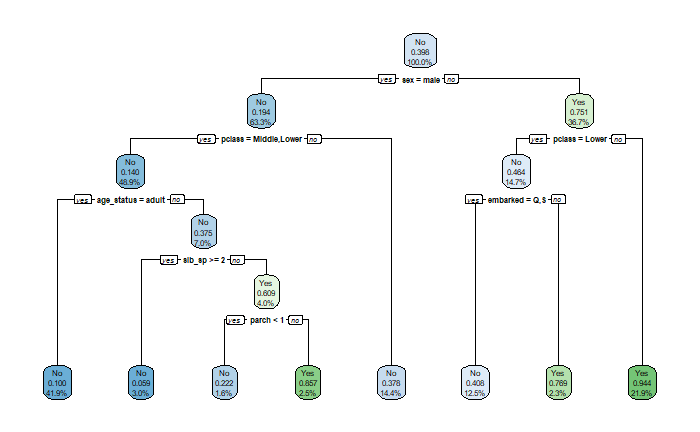

```r
titanic_fit <- rpart(
  formula = survived ~ .,
  data = titanic_train,
  method = 'class'
)

rpart.plot(titanic_fit,
           yesno = 2,
           fallen.leaves = TRUE,
           faclen = 6,
           digits = 3)
```

Case#2 - stratification

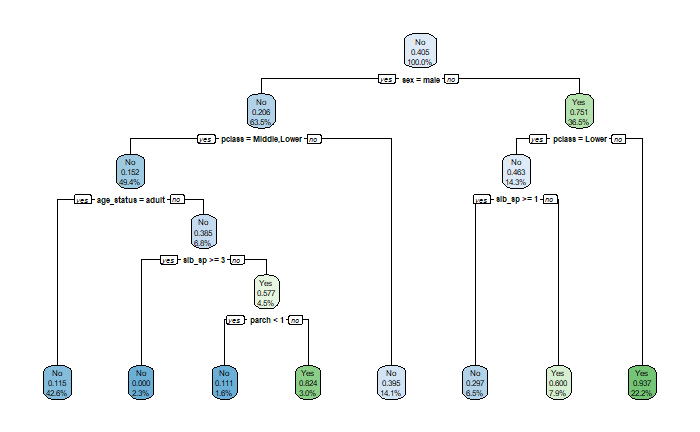

```r
titanic_fit_strat <- rpart(
  formula = survived ~ .,
  data = titanic_train_strat,
  method = 'class'
)

rpart.plot(titanic_fit_strat,
           yesno = 2,
           fallen.leaves = TRUE,
           faclen = 6,
           digits = 3)
```

## Question 5

Write down what this tells you, in detail. What variables are important? What does each node tell you? Who has the highest chance of surviving? Who has the lowest? Provide as much detail as you can.

## Question 6

Test and add your predictions to your data. Create a confusion matrix. Write down in detail what this tells you for this specific dataset.

**Ans**

Add predictions on test dataset:

```r
library(modelr)

# add the predictions
titanic_test_strat_pred <- titanic_test_strat %>%
  add_predictions(titanic_fit_strat, type = 'class')
```

```r
# look at the variables
titanic_test_strat_pred %>%
  select(sex, pclass, age_status, sib_sp, parch, pred)
```

| sex | pclass | age_status | sib_sp | parch | pred |
| --- | --- | --- | --- | --- | --- |
| female | Middle | adult | 0 | 1 | Yes |
| female | Middle | adult | 0 | 0 | Yes |
| female | Middle | adult | 1 | 2 | Yes |
| female | Middle | adult | 0 | 0 | Yes |
| female | Middle | adult | 0 | 0 | Yes |
| female | Middle | adult | 0 | 0 | Yes |
| female | Middle | adult | 0 | 0 | Yes |
| female | Middle | adult | 3 | 0 | Yes |
| female | Middle | adult | 0 | 0 | Yes |
| female | Middle | adult | 1 | 0 | Yes |

[output cut: 129 more lines]

Create confusion matrix:

```r
library(yardstick)

conf_mat <- titanic_test_strat_pred %>%
              conf_mat(truth = survived, estimate = pred)

conf_mat
```

```
          Truth
Prediction No Yes
       No  75  21
       Yes  8  35
```

```r
tibble(
  accuracy = accuracy(titanic_test_strat_pred, truth = survived, estimate = pred)$.estimate,
  sensitivity = sensitivity(titanic_test_strat_pred, truth = survived, estimate = pred)$.estimate,
  specificity = specificity(titanic_test_strat_pred, truth = survived, estimate = pred)$.estimate
)
```

| accuracy | sensitivity | specificity |
| --- | --- | --- |
| 0.7913669 | 0.9036145 | 0.625 |

Alternative way: Calculate the confusion matrix and accuracy using `caret` package:

```r
library(caret)

confusionMatrix(titanic_test_strat_pred$pred, titanic_test_strat_pred$survived) #order is estimate and then truth
```

```
Confusion Matrix and Statistics

          Reference
Prediction No Yes
       No  75  21
       Yes  8  35

               Accuracy : 0.7914
                 95% CI : (0.7143, 0.8556)
    No Information Rate : 0.5971
    P-Value [Acc > NIR] : 9.087e-07

                  Kappa : 0.5494

 Mcnemar's Test P-Value : 0.02586

            Sensitivity : 0.9036
            Specificity : 0.6250
         Pos Pred Value : 0.7812
         Neg Pred Value : 0.8140
             Prevalence : 0.5971
         Detection Rate : 0.5396
   Detection Prevalence : 0.6906
      Balanced Accuracy : 0.7643

       'Positive' Class : No
```

# Extension

See how a `ranger()` random forest classifier compares with a single decision tree in terms of performance. Can you tune the values of the `mtry`, `splitrule` and `min.node.size` hyperparameters? Which variables in the dataset turn out to be most important for your best model? The `Kappa` metric might be the best one to focus on if you want to improve performance for an imbalanced data set. Do some research on the definition of `Kappa` before you start.

We provide the code in the dropdown below if you get stuck, but still want to play around with this (note that run time can be up to 5-10 mins for the tuning). **Save your notebook before you begin** in case you need to force quit your session!

**Code**

```r
library(ranger)

control <- trainControl(
  method = "repeatedcv",
  number = 5,
  repeats = 10
)

tune_grid = expand.grid(
  mtry = 1:6,
  splitrule = c("gini", "extratrees"),
  min.node.size = c(1, 3, 5)
)
```

```r
rf_tune <- train(
  survived_flag ~ .,
  data = titanic_train,
  method = "ranger",
  metric = "Kappa",
  num.trees = 1000,
  importance = "impurity",
  tuneGrid = tune_grid,
  trControl = control
)

plot(rf_tune)
rf_tune
```

[output not shown]